# Attendance Rate VS Dropout Rate

Ranjitha Elaprolu

11/07/2017

### R Plots for Graphical Representation on the research Question

```r
library(readxl)

library(ggrepel)
```

```r
library(ggplot2)
```

Create a dataframe for the dataset, cleaned the dataset.

```r
setwd("C:/users/Ramya/Documents")
set2 <- readxl::read_xlsx("Set 2.xlsx")
set2 <- set2[set2$`Attendance Rate` > -1,]
```

## Basic Plot on Dropout rate VS Attendance Rate

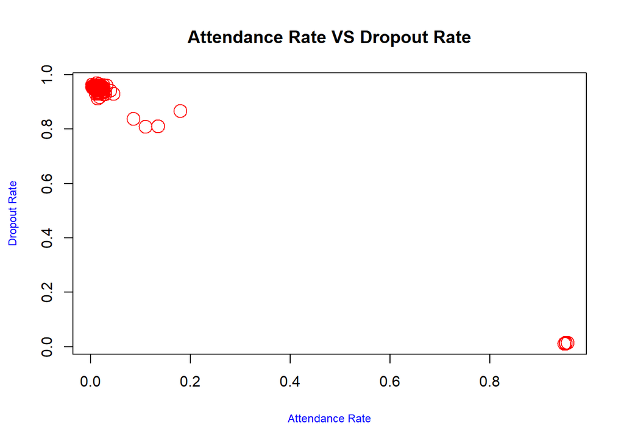

```r
plot(set2$`Attendance Rate`,set2$`Dropout Rate`, main = "Attendance Rate VS Dropout Rate",xlab = "Attendance Rate",ylab = "Dropout Rate",col.lab="blue",cex.lab=0.75,cex=2,col="red")
```

### ggplot for Attendance rate VS Dropout rate.

Plotted the ggplot with point and smooth function which gives a layerof smooth surface covering the scattered points based on the values. This is a clear and easy understanding to interpret how the dropout rate has been dropped for increasing attendance rate.

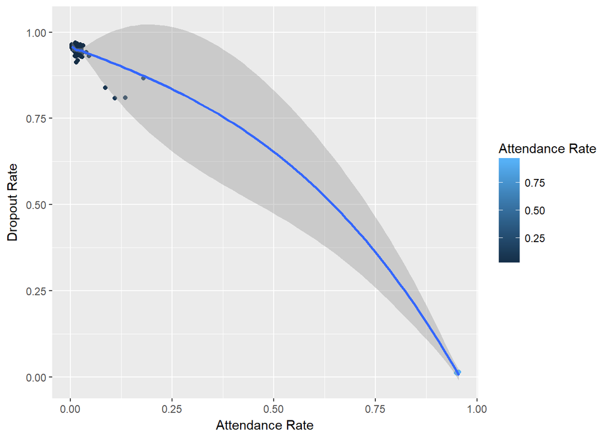

```r
p1 <- ggplot(set2, aes(x = `Attendance Rate`, y = `Dropout Rate`))
p1 + geom_point(aes(color = `Attendance Rate`)) +  geom_smooth()
```

### ggplot: Attendance rate VS Dropout rate for year 2015-2016.

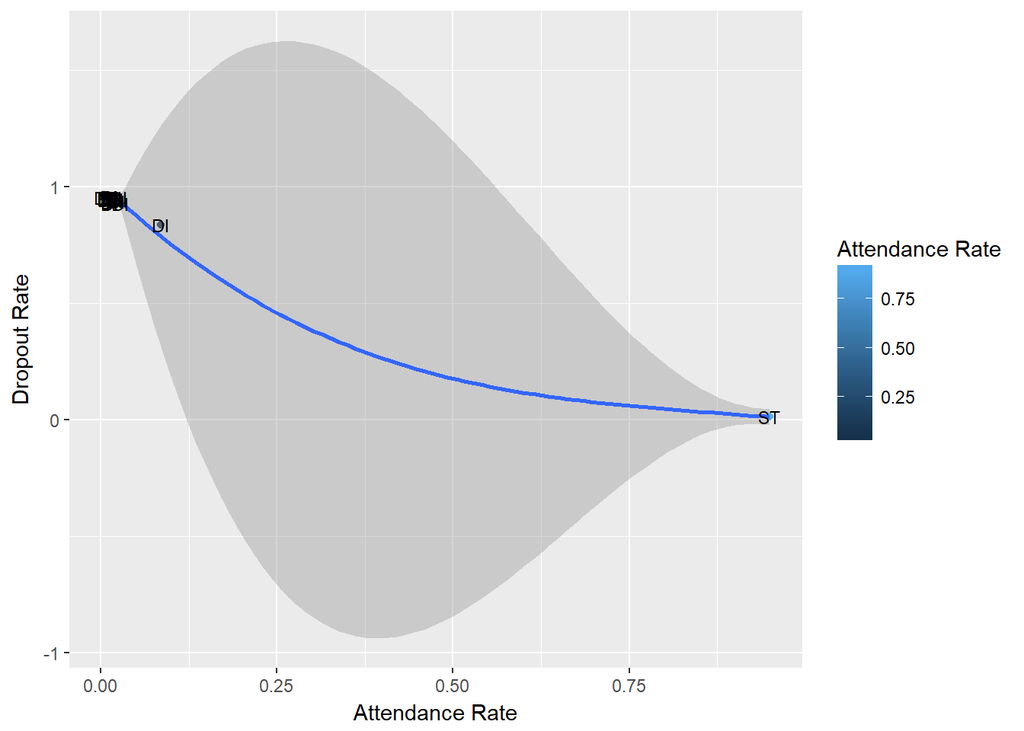

```r
yr20152016 <- set2[set2$`School Year`== 20152016, ]
p1 <-  ggplot(yr20152016, aes(x = `Attendance Rate`, y = `Dropout Rate`, main ="Year 2015-2016"))
p1 + geom_point(aes(color = `Attendance Rate`)) +  geom_smooth() + geom_text(aes(label=Type),size=3)
```

### ggplot: Log Attendance rate VS Dropout rate for year 2015-2016.

Applied arthimetic function log on the attendance rate column to display and scattered value which gives a clear picture on the decreaing dropout rate for increasing attendance rate.  
That is being displayed in the below Graph.

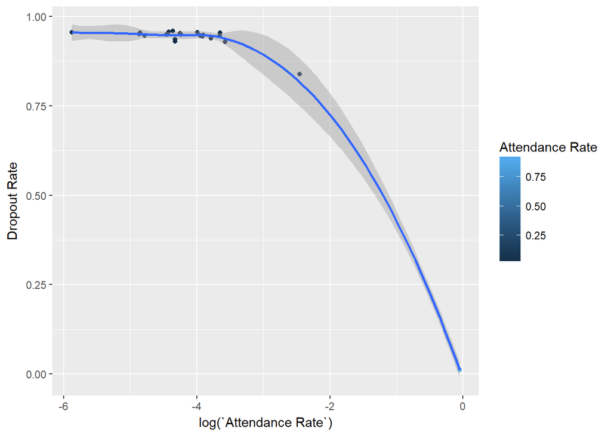

```r
p1 <-  ggplot(yr20152016, aes(x = log(`Attendance Rate`), y = `Dropout Rate`))
p1 + geom_point(aes(color = `Attendance Rate`)) +  geom_smooth()
```

### Research Question: Does the percentage of teachers with masters degree has an impact on Students Dropout Rate

### R Plots for Graphical Representation on the research Question

```r
library(readxl)

library(ggrepel)

library(ggplot2)
```

Create a dataframe for the dataset, cleaned the dataset.

```r
setwd("C:/users/Ramya/Documents")
set3 <- readxl::read_xlsx("Set 3.xlsx")
set3 <- set3[set3$`Dropout Rate` > -1,]
```

#### Basic plot on Teachers with master’s degree VS Dropout Rate.

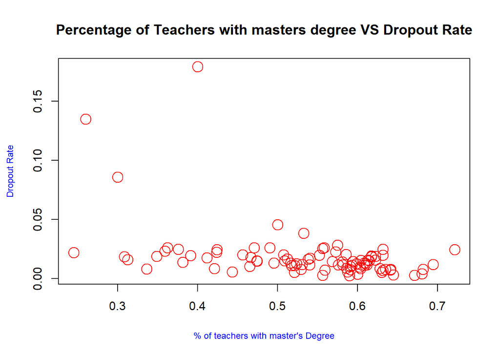

```r
plot(set3$`Teachers with Masters Degree`,set3$`Dropout Rate`,main = "Percentage of Teachers with masters degree VS Dropout Rate",xlab = "% of teachers with master's Degree",ylab = "Dropout Rate",col.lab="blue",cex.lab=0.75,cex=2,col="red")
```

### Group: School Year on Teachers with masters degree VS Dropout Rate.

#### ggplot on Teachers with master’s degree VS Dropout Rate.

- Using ggplot created the plot for the same parameters.
- And then used the facet function to split the plot based on the school year.
- By this we will know which year we had many dropout rates.

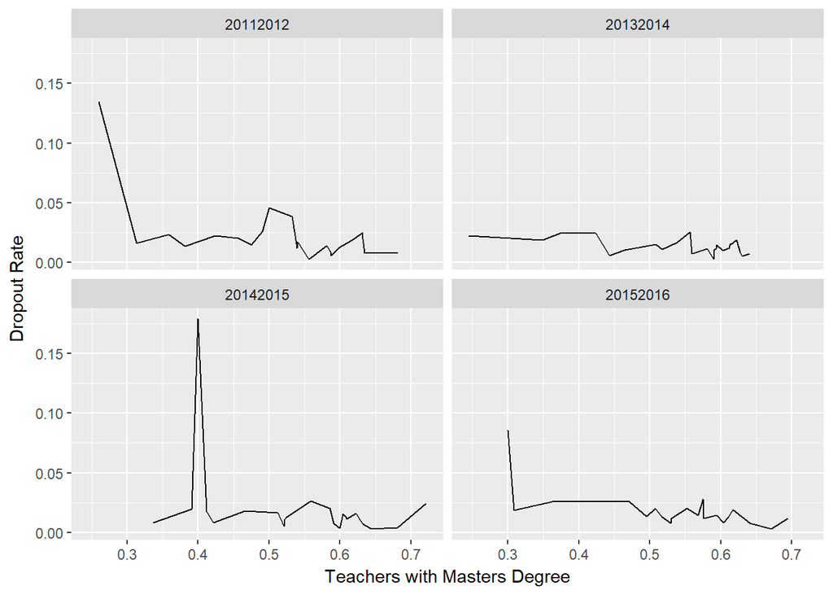

```r
plt1 <- ggplot(set3, aes(x = `Teachers with Masters Degree`, y = `Dropout Rate`))
(plt2 <- plt1 + geom_line() + facet_wrap(~`School Year`))
```

### Group County wise Teachers with masters degree VS Dropout Rate.

#### ggplot for teachers with masters degree VS Dropout Rate.

Created the plot using ggplot package. I had interpreted the data for each county on the same parameters.  
By this we can figure out which school had the varying dropout rate with respect to percentage of teachers with masters degree.

[output not shown]

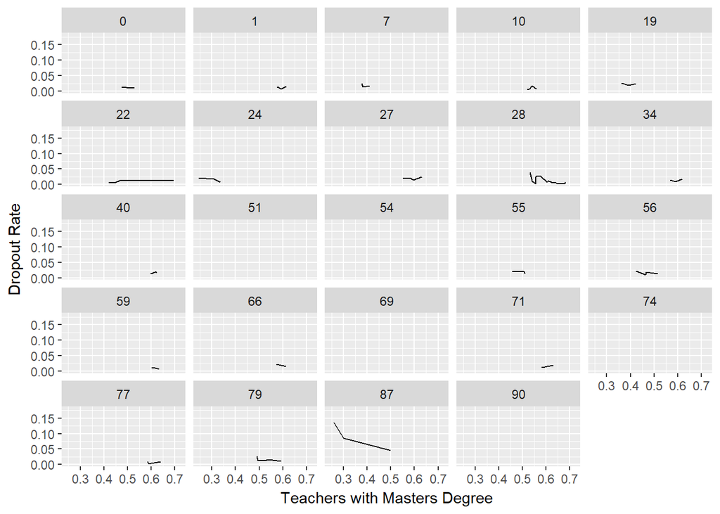

```r
plt1 <- ggplot(set3, aes(x = `Teachers with Masters Degree`, y = `Dropout Rate`))
(plt2 <- plt1 + geom_line() + facet_wrap(~`County`))
```